# Testing the meta-ecosystem framework along the river-sea continuum

## Todo

- Join food web structure metrics with hydrographic/sea-mesh distance to river mouth (signed: river negative, sea positive)
- Trophic length, connectance and species richness vs. signed distance, split by watershed
- Zoom on the river-sea transition zone, check for a discontinuity at the mouth
- Check whether the pattern is stable across years
- **(open)**

## Setup

```r
library(renv)
renv::load()
library(targets)
library(here)
tar_config_set(
  store = here::here("_targets")
)
library(ggplot2)
library(dplyr)
devtools::load_all()
nice_theme()
```

## Data preparation

We join each local food web’s structure metrics (`foodweb_structure`) with its hydrographic distance to the nearest river mouth (`distance_to_mouth`, built in D8: channel-length distance on the river side, water-mesh distance on the sea side). `inland` marks which of the two was used to compute `dist_mouth_m`. We turn this into a single signed distance in km, negative upstream (river) and positive offshore (sea), so the river-sea transition sits at 0.

```r
foodweb_structure <- tar_read(foodweb_structure)
distance_to_mouth <- tar_read(distance_to_mouth)

fw_dist <- foodweb_structure |>
  inner_join(
    distance_to_mouth |> select(operation_id, district, dist_mouth_m, inland),
    by = "operation_id"
  ) |>
  mutate(
    dist_mouth_km = ifelse(inland, -1, 1) * dist_mouth_m / 1000,
    species_richness = exp(log_species_richness)
  )

cat(sprintf(
  "%d / %d local food webs matched to a distance-to-mouth value (%d dropped, outside the four watersheds kept in D8)\n",
  nrow(fw_dist), nrow(foodweb_structure), nrow(foodweb_structure) - nrow(fw_dist)
))
```

```
14299 / 17038 local food webs matched to a distance-to-mouth value (2739 dropped, outside the four watersheds kept in D8)
```

```r
side_lab <- c(`TRUE` = "River", `FALSE` = "Sea")

plot_metric_vs_distance <- function(data, metric, ylab) {
  ggplot(data, aes(dist_mouth_km, .data[[metric]], color = survey)) +
    geom_point(alpha = 0.15, size = 0.5) +
    geom_smooth(se = TRUE) +
    geom_vline(xintercept = 0, linetype = "dashed", color = "grey30") +
    scale_color_discrete(name = NULL) +
    labs(x = "Distance to river mouth (km)", y = ylab)
}
```

## Trophic length, connectance and richness vs. distance to mouth, by watershed

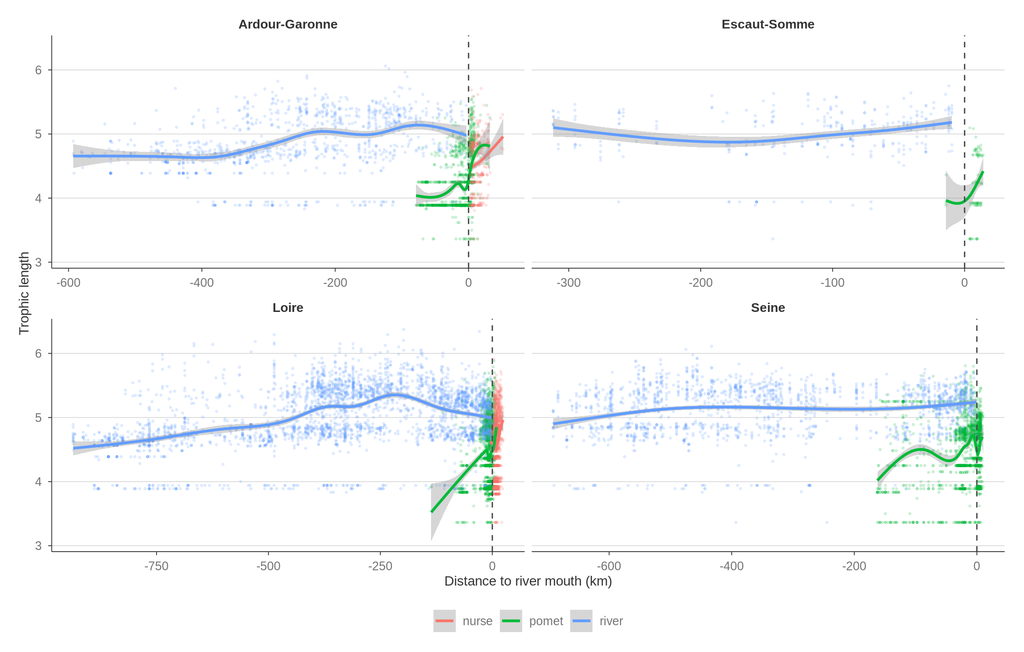

```r
plot_metric_vs_distance(fw_dist, "trophic_length", "Trophic length") +
  facet_wrap(~district, scales = "free_x")
```

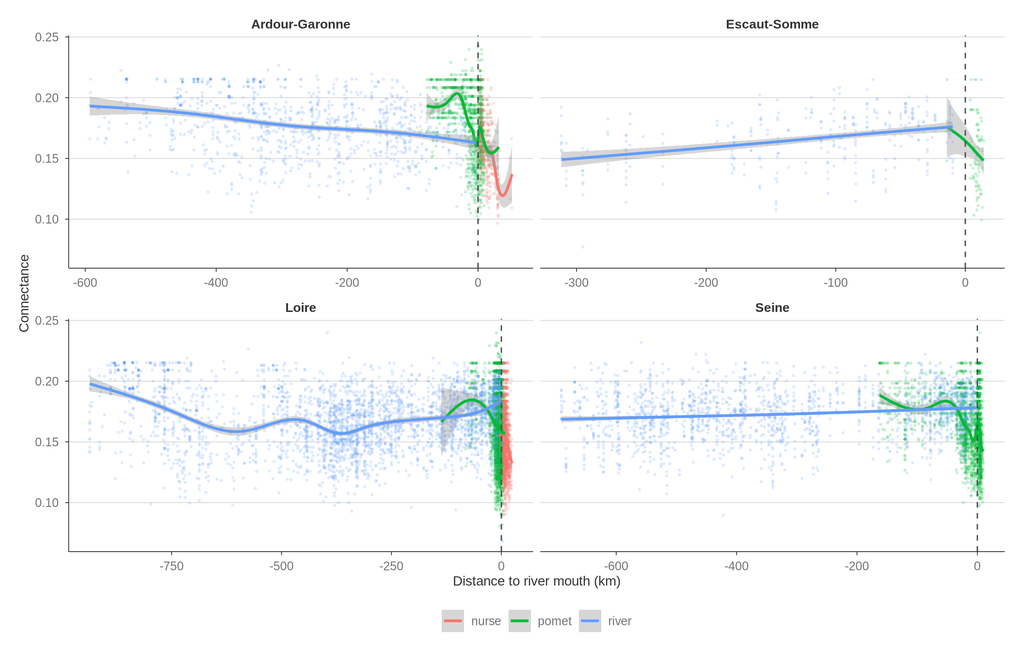

```r
plot_metric_vs_distance(fw_dist, "connectance", "Connectance") +
  facet_wrap(~district, scales = "free_x")
```

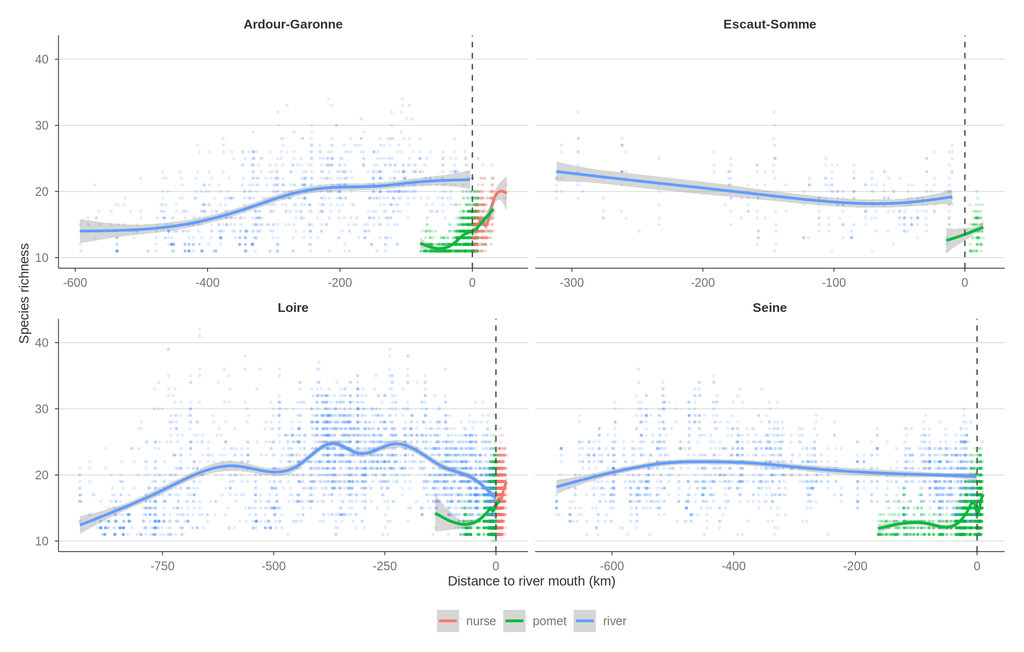

```r
plot_metric_vs_distance(fw_dist, "species_richness", "Species richness") +
  facet_wrap(~district, scales = "free_x")
```

## Transition zone

Zooming on ()20km around the mouth, and a direct numeric comparison of the two sides within ()5km.

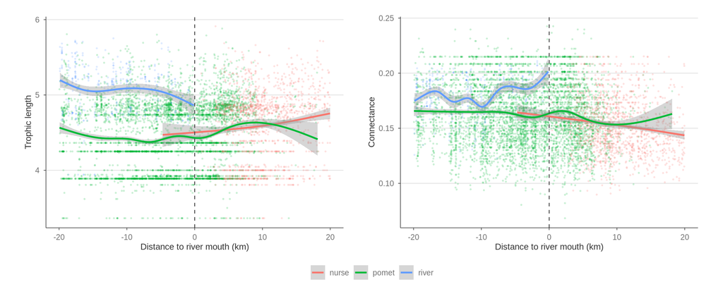

```r
zoom <- fw_dist |> filter(abs(dist_mouth_km) <= 20)

patchwork::wrap_plots(
  plot_metric_vs_distance(zoom, "trophic_length", "Trophic length"),
  plot_metric_vs_distance(zoom, "connectance", "Connectance"),
  nrow = 1
) +
  patchwork::plot_layout(guides = "collect") &
  theme(legend.position = "bottom")
```

```r
near_summary <- fw_dist |>
  filter(abs(dist_mouth_km) <= 5) |>
  mutate(side = side_lab[as.character(inland)]) |>
  group_by(side) |>
  summarise(
    n = n(),
    mean_trophic_length = mean(trophic_length),
    mean_connectance = mean(connectance),
    .groups = "drop"
  )
knitr::kable(near_summary, digits = 3)
```

| side | n | mean_trophic_length | mean_connectance |
| --- | --- | --- | --- |
| River | 1285 | 4.469 | 0.162 |
| Sea | 1499 | 4.487 | 0.164 |

*To discuss: is there an actual step/discontinuity right at the mouth, or a smooth crossing - the ()5km means look close for both metrics, but the zoomed scatter above should be checked directly rather than trusting the smoother’s behavior at the boundary.*

## Temporal stability

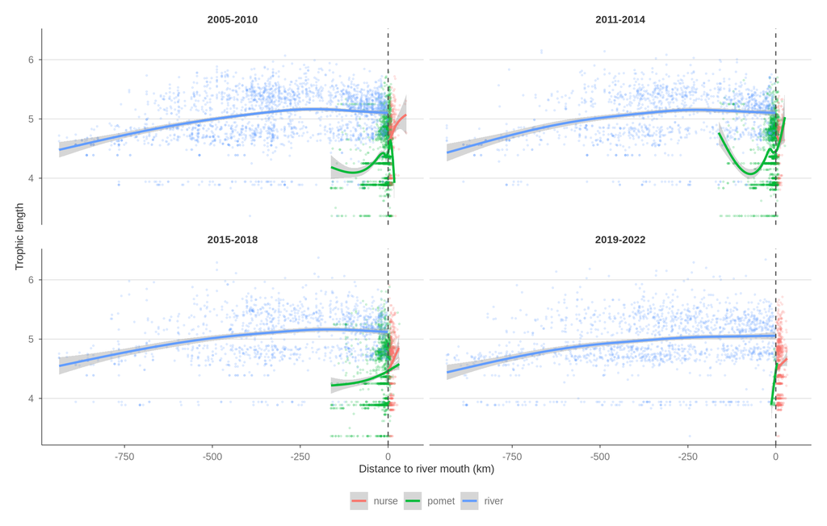

```r
fw_dist_year <- fw_dist |>
  mutate(
    year_bin = cut(
      year,
      breaks = c(2004, 2010, 2014, 2018, 2023),
      labels = c("2005-2010", "2011-2014", "2015-2018", "2019-2022")
    )
  )

plot_metric_vs_distance(fw_dist_year, "trophic_length", "Trophic length") +
  facet_wrap(~year_bin)
```

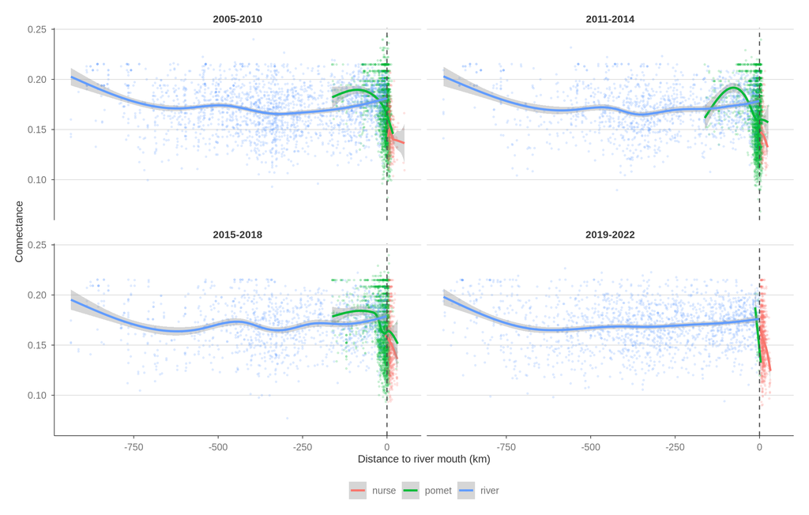

```r
plot_metric_vs_distance(fw_dist_year, "connectance", "Connectance") +
  facet_wrap(~year_bin)
```